# Vector Geometry in $R^n$

Geometric vectors in 2, 3 and $n$-space have 2 characteristics:

1. Direction
2. Length (magnitude)

We often represent vectors as arrows in $n$-space.

If a coordinate system is not used then any two vectors with the same direction and magnitude are equal (free vectors).

If a coordinate system is used then vectors are only equal if they also have the same start point (position vectors).

## Vector Addition & Subtraction

Position start points for vectors at the origin.

Then $v + w$ has a geometric interpretation as the location of the opposite vertex of a parallelogram.

Or, just as good: let $w$ start at the end point of $v$ and form a triangle - the closing side of that triangle is the vector $v+w$.

E.G.

$$ v=\begin{bmatrix}2 \\3 \end{bmatrix} \quad w=\begin{bmatrix}-1 \\4 \end{bmatrix} $$

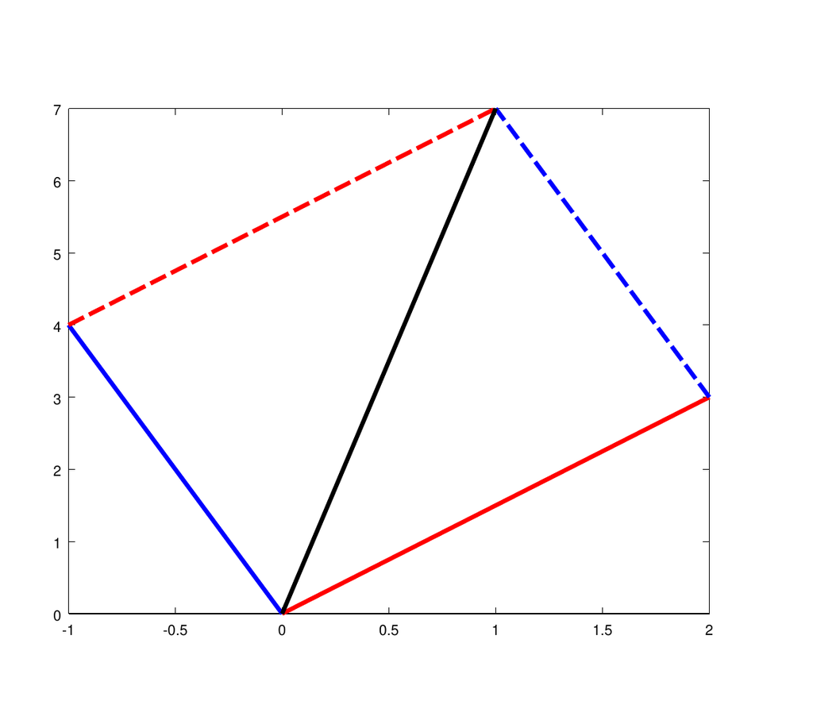

### Translation & Subtraction

Move the end point of $v$ in the direction of $w$ by the length of $w$ - we get the 'translation of $v$ by $w$'.

Clearly: $v+w=w+v$.

The vector $-v$ has the same length as $v$ but opposite direction.

We get vector subtraction as follows:

$$ w-v = w + (-v) $$

and we use the usual addition rules.

### Scalar multiplication

A vector multiplied by a scalar, e.g. $av$ is the vector $v$ with its length multiplied by $a$ for $a>0$. If $a<0$ the the result is a vector with length of $av$ but with opposite direction to $a$.

We use these rules for 3 or more vectors recursively, and for vectors in 3-D.

In 3-D we say adding 3 vectors gives the location of the opposite vertex of the parallelepiped (from the origin) defined by vectors.

e.g. $$ u=\begin{bmatrix}1 \\2\\3 \end{bmatrix} \quad v=\begin{bmatrix}0 \\4\\1 \end{bmatrix} \quad w=\begin{bmatrix}3 \\1\\2 \end{bmatrix} $$

Therefore: $$ u+v+w=\begin{bmatrix} 4 \\ 7 \\6 \end{bmatrix} $$

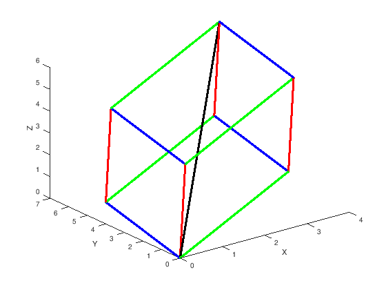

```matlab
graphics_toolkit ("fltk");
 set(gcf,'Visible','on')
% vector plots adding three vectors

hold off;
plot3([0 1],[0 2],[0 3],'linewidth',2,'color','red');
xlabel('X');ylabel('Y');zlabel('Z');
line([0 0],[0 4],[0, 1],'linewidth',2,'color','blue');
line([0 3],[0 1],[0 2],'linewidth',2,'color','green');
line([0 4],[0 7],[0 6],'linewidth',2,'color','black');

line([1 1],[2 6],[3, 4],'linewidth',2,'color','blue');
line([3 3],[1 5],[2, 3],'linewidth',2,'color','blue');
line([4 4],[3 7],[5, 6],'linewidth',2,'color','blue');

line([1 4],[6 7],[4, 6],'linewidth',2,'color','green');
line([0 3],[4 5],[1, 3],'linewidth',2,'color','green');
line([1 4],[2 3],[3, 5],'linewidth',2,'color','green');

line([0 1],[4 6],[1, 4],'linewidth',2,'color','red');
line([3 4],[5 7],[3, 6],'linewidth',2,'color','red');
line([3 4],[1 3],[2, 5],'linewidth',2,'color','red');
```

### Some notation and definitions

Point to Point notation:

We can say the vector $\overrightarrow{pq}$ is the vector from point $(p_1, p_2)$ to $(q_1, q_2)$. Denoting the origin as $0=(0,0)$ etc. we can say our vectors starting at the origin are also: $\overrightarrow{0v}$ or $\overrightarrow{0w}$.

In this case the vector from point $v$ to point $w$ is given as $\overrightarrow{0u}$ where $u=(w_1-v_1, w_2-v_2)$

Often the following notation is used (assumes coordinate system is being used):

- $\mathbf{R}^1=$ 1-D number line.
- $\mathbf{R}^2=$ 2-D coordinate space.
- $\mathbf{R}^3=$ 3-D coordinate space.
- $\mathbf{R}^n=$ $n$-D coordinate space.

All are Euclidean $n$ spaces.

## Linear Combinations:

$$ q=k_1u + k_2v+k_3w $$

The vector $q$ is a linear combination of vectors $u, \ v,\ w$ with coefficients $k_1, \ k_2, \ k_3$.

This allows all vectors to be represented as linear combinations of the standard unit vectors.

The standard unit vectors are length 1 vector along the axes in the positive direction. $$ v=\begin{bmatrix}0 \\4\\1 \end{bmatrix} =0\begin{bmatrix}1 \\0\\0 \end{bmatrix} +4\begin{bmatrix}0 \\1\\0 \end{bmatrix} +1\begin{bmatrix}0 \\0\\1 \end{bmatrix} $$

### Vector Norms

Norm = length of the vector.

Using Pythagoras we get: $$\begin{align} \mathbf{R}^2:\quad \|v\| &= \sqrt{v_1^2+v_2^2} \qquad \mathbf{R}^3:\quad \|w\| = \sqrt{w_1^2+w_2^2+w_3^2}\\ \\ \mathbf{R}^n:\quad \|u\| &= \sqrt{u_1^2+u_2^2+u_3^2+\ldots+u_n^2} \end{align} $$

We also get: $$ \|kv\| = |k\|v\|, \qquad \frac{v}{\|v\|}=u\Rightarrow \|u\|=1 $$ The last result is called 'normalising' the vector $v$.

### Distance between vectors

This is defined to be the distance between the end points of the vectors. It can be found as: $$ \|w-v\| = \sqrt{(w_1-v_1)^2+(w_2-v_2)^2+\ldots+(w_n-v_n)^2} $$

### Dot product (aka: Inner product)

Problem: Find the angle (degrees say) between two vectors.

The angle will be defined as the non-reflex angle (180$^{\circ}$ or less).

Using the law of cosines we get: $$ \theta = cos^{-1} \left( \frac{v\cdot w}{\|v\|\|w\|} \right) $$

Where,

$$ v\cdot w = v'w = v_1w_1 + v_2+w_2 + \ldots + v_nw_n $$

[proof?]

Nb: If $v\cdot w=0$ then $\theta=90^{\circ}$ - a very quick way to establish that vectors are perpendicular (orthogonal).

### Cauchy-Schwarz inequality

Can we always get the angle using the above formula?

Yes if we can show that:$$ \frac{|v\cdot w|}{\|v\|\|w\|} \leq 1 $$

This is proved using the Cauchy-Schwarz inequality which states:

$$ \left(\sum_{i=1}^{n}x_iy_i\right)^2 \leq \sum_{i=1}^{n}x_i^2 \sum_{i=1}^{n}y_i^2 $$

[proof?]

**Properties of Dot Products (to be proved)**

1. $v\cdot u=u\cdot v$
2. $u\cdot (v+w)=u\cdot v+u\cdot w$
3. $ku\cdot v=uk\cdot v=u\cdot kv=u\cdot vk\quad... \qquad \qquad [\mbox{scalar } k]$
4. $v\cdot v\geq 0$ and $v\cdot v=0 \quad iff \ \ v_i=0 \ \forall \ i$
5. $\|u+v\|^2 = \|u\|^2+\|v\|^2+2u\cdot v$

**Triangle Inequality** $$ \|v+w\|\leq \|v\|+\|w\| $$

[proof?]

### Equations of Lines \& Planes: Lines in $R^2$

#### Lines in $R^2$

1. **Standard Form:**

$$ L: \qquad ax+by+c=0 $$

for coefficients $a,\ b,\ c$.

Nb: slope intercept form is a rearrangement of standard form to: $$ y=-\frac{c}{b}-\frac{a}{b}x $$

1. **Vector Form:**

$$ L: \qquad \begin{bmatrix} x_0 \\ y_0 \end{bmatrix}+t \begin{bmatrix} v_1 \\ v_2 \end{bmatrix} $$

for parameter, $-\infty < t < \infty$, where $v$ is a vector parallel to $L$ and $(x_0,y_0)$ is a point on the line.

#### Examples 2.1

Find the two forms for the following lines:

1. The line passing through points $(1,2)$ and $(3,8)$.
2. The two points $p(-2,4)$ and $q(1, -3)$ are on this line.
3. The line passing through the point $p(2,4)$ making a positive (anti clockwise) 45 degree angle with the positive x-axis.
4. $$ L: \begin{bmatrix} 0\cr 3 \end{bmatrix}+t \begin{bmatrix} 1 \\ 0 \end{bmatrix}$$

## Equations of Lines in $R^3$

1. **Standard Form:**

Given as the intersection of two planes in standard form - see below.

1. **Vector Form:**

$$ L: \begin{bmatrix} x_0\cr y_0\cr z_0 \end{bmatrix}+t \begin{bmatrix} v_1 \\ v_2 \\ v_3 \end{bmatrix} \qquad [-\infty < t < \infty]$$

### Equations of Planes in $R^3$

1. **Standard Form:** $$ P: \qquad ax+by+cz+d=0 $$ for coefficients $a,\ b,\ c,\ d$ .
2. **Vector Form:** $$ P: \qquad \begin{bmatrix} x_0 \\ y_0 \\ z_0\end{bmatrix}+t \begin{bmatrix} v_1 \\ v_2 \\ v_3\end{bmatrix}+s \begin{bmatrix} w_1 \\ w_2 \\ w_3\end{bmatrix} $$ for parameters, $-\infty < t,s < \infty$, where $v$ and $w$ are non-collinear vectors in the plane (parallel to the plane) and $(x_0,y_0,z_0)$ is a point on the plane.

Question: How do you establish of two vectors are collinear or non-collinear?

**Examples 2.2**  
Find the two forms for the following.

1. The plane containing points $(1,1,2)$, $(0,-3,4)$ and $(2,3,5)$.
2. The equation of the planes for the 'Modern package' and 'Classic package' of the Furniture Sales problem. Determine the intersection of these planes - what do you notice?
3. Find vector & standard forms for the line through $p(-6, 2, 5)$ and $q(0, 5, 17)$

NB: There are other ways to formulate lines and planes in $R^2$ and $R^3$ - these are two that happen to be of relevance of us.

## Matrix Determinants

Prove the following:

$$ A=\begin{bmatrix} a & b \\ c & d\end{bmatrix}\quad \Rightarrow A^{-1} =\frac{1}{ad-bc}\begin{bmatrix} d & -b \\ -c & a\end{bmatrix} $$

where $ad-bc$ is the determinant of $A$ or $|A|$, and $\begin{bmatrix} d & -b \\ -c & a\end{bmatrix}$ is called the adjoint matrix.

The determinant of $A$ is variously written as $det(A)$ or $|A|$.

### Inverse of $3\times 3$ Matrix

Can we do the same for a $3\times 3$ or more generally for an $n \times n$ matrix?

Yes - but remember its still more efficient to find inverses using elimination!

Minors: The minor of a matrix entry is denoted $M_{ij}$ and is the determinant of the sub-matrix formed by deleting the $i$th row and $j$th colum of the matrix.

Cofactors: This is the minor multiplied by either $1$ or $-1$ - given by $C_{ij}=(-1)^{(i+j)}M_{ij}$

#### Checkerboard Pattern

$(-1)^{(i+j)}$ produces a checkerboard pattern as follows: $$ \begin{bmatrix} + & - \\ - & +\end{bmatrix} \qquad \begin{bmatrix} + & - & + \\ - & + & - \\ + & - & +\end{bmatrix} \qquad \begin{bmatrix} + & - & + & - & \cdots \\ - & + & - & + & \cdots\\ + & - & + & - & \cdots \\\vdots & \vdots & \vdots & \vdots \end{bmatrix} $$

### Determinant by Cofactor expansion

$$\begin{align} det(A) &= a_{1j}C_{1j}+ a_{2j}C_{2j} + \cdots + a_{nj}C_{nj} \qquad ,\forall j\\ &= a_{i1}C_{i1} + a_{i2}C_{i2} + \cdots + a_{in}C_{in} \qquad \ \ ,\forall i\end{align} $$

E.G: Find the determinants of: $$ A=\begin{bmatrix} 3 & 1 & 0 \\ -2 & -4 & 3\\ 5 & 4 & -2\end{bmatrix} \qquad B=\begin{bmatrix} 5 & -2 & 4 & -1\\ 0 & 1 & 5 & 2\\ 1 & 2 & 0 & 1\\ -3 & 1 & -1 & 1\\ \end{bmatrix} $$

### Triangular Matrices

$$ A=\begin{bmatrix} a_{11} & 0 & 0 & 0 & 0\\ a_{21} & a_{22} & 0 & 0 & 0\\ a_{31} & a_{32} & a_{33} & 0 & 0\\ a_{41} & a_{42} & a_{43} & a_{44} & 0\\ \vdots & \vdots &\vdots & \vdots& \ddots \end{bmatrix} $$

Show that $det(A)=\prod_{i=1}^{n}a_{ii}$ for triangular matrices and hence find the determinant of:

$$ A=\begin{bmatrix} 1 & 0 & 0 & 0 \\ 3 & 2 & 0 & 0\\ 7 & 9 & 5 & 0\\ 7 & 0 & 3 & 1 \end{bmatrix} $$

## Determinant via row reduction

1. Idea: row reduce matrix $A$ to an upper triangular and get the determinant (easy!) of the resulting matrix.
2. Problem: What happens to $|A|$ under row reduction?

**Properties of the determinant**

1. Multiply row $i$ of $A$ by a constant $k$ or column $j$ by $k$ to give a new matrix $B$ and $|B|=k|A|$
2. Let $B=A'$. Then $|B|=|A|$.
3. Swap two rows or columns of $A$ to give a new matrix $B$ and we get $|B|=-|A|$.
4. If $A$ has two equal rows the $|A|=0$.
5. $|A|$ is unchanged by a multiple of one row being added to another row.

## Matrix inverse using the determinant

Give an $n\times n$ matrix $A$, its cofactor matrix is:

$$ C=\begin{bmatrix}C_{11} & C_{12} & \cdots & C_{1n}\\ C_{21} & C_{22} & \cdots & C_{2n}\\ \vdots\\ C_{n1} & C_{n2} & \cdots & C_{nn}\\ \end{bmatrix} $$

The **adjoint** of $A$ is $C'$, i.e.

$$ adj(A)=\begin{bmatrix}C_{11} & C_{21} & \cdots & C_{n1}\\ C_{12} & C_{22} & \cdots & C_{n2}\\ \vdots\\ C_{1n} & C_{2n} & \cdots & C_{nn}\\ \end{bmatrix} $$

Using the fact that the determinant of a matrix with two equal rows must be zero we get:

$$ A[adj(A)]=|A|I_n \qquad \mbox{and }\qquad [adj(A)]A=|A|I_n $$

[proof?]

Therefore, the inverse of $A$ is given by:

$$ A^{-1}=\frac{1}{|A|}adj(A) $$

Find the inverse of $A$: $$ A=\begin{bmatrix} 3 & 2 & 1\\ 1 & 6 & 3\\ 2 & -4 & 0 \end{bmatrix} $$